# Math 120 Lec xx

Your Name

14 October, 2019

## Comparing Normal Distros: Z-Scores

The idea: z scores let us compare different distros.

Ex: normal distro for heights for men and women.

Z-scores give us a “level playing field” by adjusting for the center and spread.

### ACT/SAT example

The ACT and SAT exams both follow normal distributions, but each has a different center and spread. The mean score for the ACT is 21 with std dev 6, while the mean score for the SAT is 1100 with std dev 200.

A student named Abby took both exams. She scored a 28 on the ACT and a 1320 on the SAT. Which exam did she do better on? Which score would she prefer to send to schools?

How to answer? Z-scores!

ACT: z = (28 - 21)/6

```r
(28 - 21)/6
```

```
## [1] 1.166667
```

SAT

```r
(1320 - 1100)/200
```

```
## [1] 1.1
```

Abby performed better on the ACT, since z-score is higher.

The story of the z-score forumla: z scores measure the distance between an observation and the mean, measured in standard deviations.

For Abby, her ACT score was 1.167 standard devs above the mean ACT score.

Her SAT score was 1.1 std devs above the mean.

## Empirical Rule (68-95-99.7 rule)

IF X follows a normal dist, then:

About 68% of all data lies within 1 sd of the mean. About 95% of all data lies within 2 sd of the mean. About 99.7% of all data lies within 3 sd of the mean.

The empirical rule contextualizes what z scores mean.

For Abby, her z-scores were about 1.1, this is not unusual!

What if the std dev for ACT was 0.5. What would her z score be then?

```r
# zscore

(28-21)/.5
```

```
## [1] 14
```

Wooooah! From the empriical rule, we know that this is a craaazy z score! Huge! Thus, super, super unlikely!

Charlotte’s obs: we can tell if an obs is below the mean by the sign of it’s zscore: +-

Sophie: Since her z-score of 14 is way out past z=3, that means she’s grouped in with a teeeny teeeny tiny portion of the distro. (<.03%).

## Forwards and Backwards Problems

Impotant note: when we find z-scores, the new distribution has mean 0 and std dev 1. I.e., centered about zero, unit of variability is 1.

This is called the **standard normal** dist!! Normal, mean =0, std dev = 1.

When working with normal populations, we generally get the z score first to have a level playing field.

### Forwards: the “normal” way

All examples here are about human height, which follows a normal. For men, avg height is 69“, std dev 2.7”. For women, mean is 64“, std dev 2.4”.

1. What’s the probability that rando woman is 5’6" or shorter?

Find a z score:

```r
(66-64)/2.4
```

```
## [1] 0.8333333
```

Let’s find the area:

```r
# use cdf, pnorm

pnorm(.83333, 0, 1)
```

```
## [1] 0.7976707
```

Note: pnorm assumes std normal with mean=0, std = 1

```r
pnorm(.83333)
```

```
## [1] 0.7976707
```

This means that there’s a 79.77% chance that a randomly selected woman i 5’6" or shorter.

Matt: do we really need z score?

Answer: not always, but still important

```r
pnorm(66, 64, 2.4)
```

```
## [1] 0.7976716
```

2. What’s the prob that a rando man is between 5’5" and 5’10"?

I.e 65 < X < 70

```r
# z scores

# x = 65

(65-69)/2.7
```

```
## [1] -1.481481
```

```r
(70-69)/2.7
```

```
## [1] 0.3703704
```

```r
pnorm(.37)-pnorm(-1.481)
```

```
## [1] 0.5750055
```

There’s about a 57.5% chance.

3. What’s the probability that your female math teacher is taller than 6’3"?

```r
#rmember, cdf always shows area to the left.

# for right, do 1-

1-pnorm(75, 64, 2.4)
```

```
## [1] 2.288108e-06
```

.00000229. Very small!

## Verifying Normality of data

How can we verify that our data is normal?

Take a look!

1. Histogram

Ex: iris dataset. Is sepal length normal?

```r
iris %>% head
```

|  | Sepal.Length | Sepal.Width | Petal.Length | Petal.Width | Species |
| --- | --- | --- | --- | --- | --- |
| 1 | 5.1 | 3.5 | 1.4 | 0.2 | setosa |
| 2 | 4.9 | 3.0 | 1.4 | 0.2 | setosa |
| 3 | 4.7 | 3.2 | 1.3 | 0.2 | setosa |
| 4 | 4.6 | 3.1 | 1.5 | 0.2 | setosa |
| 5 | 5.0 | 3.6 | 1.4 | 0.2 | setosa |
| 6 | 5.4 | 3.9 | 1.7 | 0.4 | setosa |

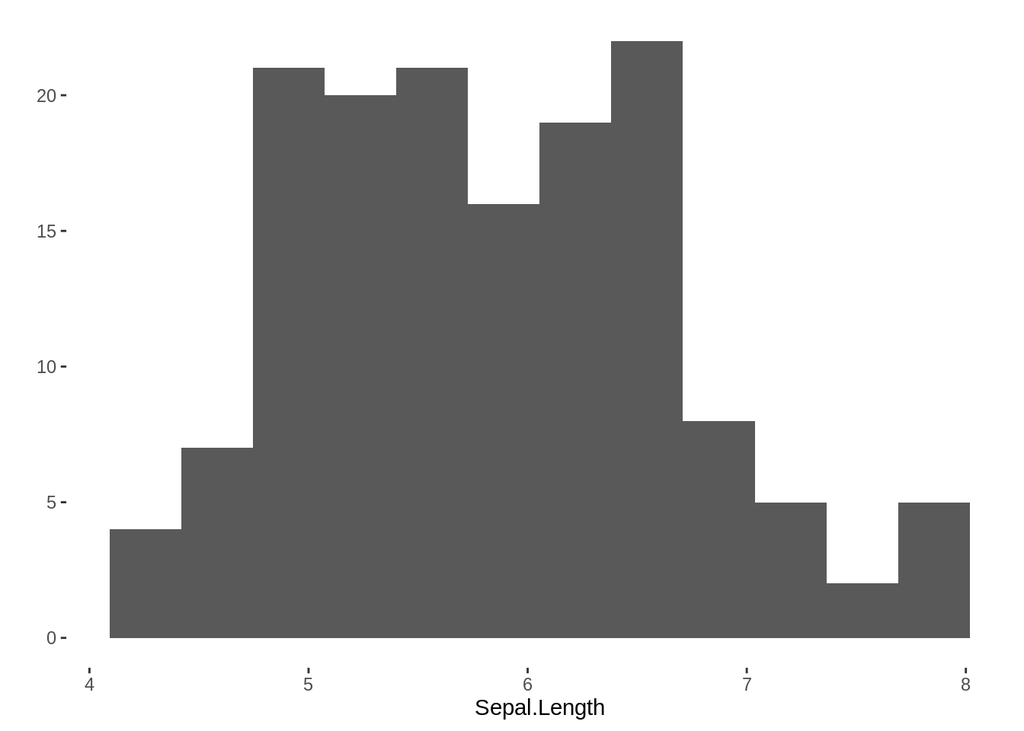

```r
qplot(Sepal.Length, data = iris, bins=12)
```

Looks like no, not normal! Bimodal, skew.

2. Normal quantile plot (qq plot)

Let’s make a qq plot for Sepal.Length

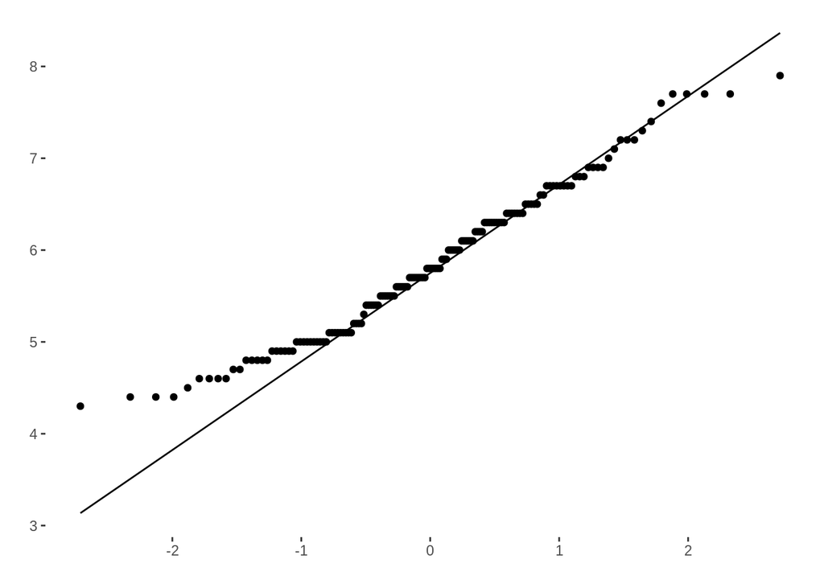

```r
qplot(data=iris, sample=Sepal.Length, geom="qq")+geom_qq_line()
```

QQ plots compare our data to reference values from the normal dist. If our data follows a normal dist, its qq plot should be linear!

Here, deviatioun from the line indicates that our data does not follow a normal.

QQ plots help us detect nuance that’s hard to see by eye.

## Normal distributions are -everywhere!-